# Tarification d’une rente viagère et projection de la mortalité par le modèle de Lee-Carter.

Groupe 1

5/9/2021

## Chargement des packages

```r
library(lifecontingencies)
library(reliaR)
library(StMoMo)
library(demography)
library(fanplot)
```

## Téléchargement des données pour l’UK

```r
UK_females<-read.table(file = file.choose(),header = TRUE,skip=1 ,sep = "", dec = ".")
head(UK_females)
```

```
##   Year Age      mx      qx   ax     lx   dx    Lx      Tx    ex
## 1 1922   0 0.07005 0.06684 0.31 100000 6684 95415 5885053 58.85
## 2 1922   1 0.02498 0.02467 0.50  93316 2302 92165 5789637 62.04
## 3 1922   2 0.01214 0.01207 0.50  91014 1098 90465 5697473 62.60
## 4 1922   3 0.00607 0.00605 0.50  89916  544 89643 5607008 62.36
## 5 1922   4 0.00443 0.00442 0.50  89371  395 89174 5517364 61.74
## 6 1922   5 0.00386 0.00385 0.50  88977  343 88805 5428191 61.01
```

## Préparation des données

1. Sélection de la cohorte nés en 1960
2. Transfomation des données en dataframe
3. Changement du type de la variable Age de fatcor à numérique

```r
UK <- hmd.mx(country = "GBR_NP",username = "khalil.bagbag1@esprit.tn",password = "1620595063",label = "UK")
```

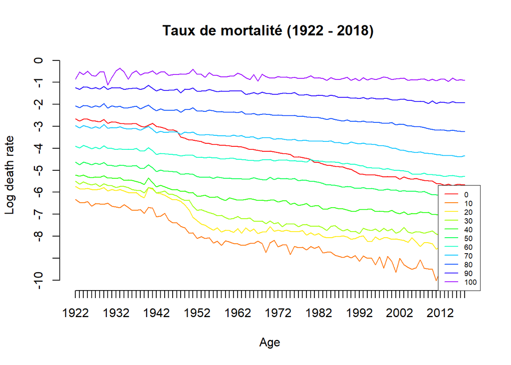

```r
# Choix de la période de calibration des données :
par(mfrow=c(1,1))
UK_ages = c(0,10,20,30,40,50,60,70,80,90,100)

plot(UK,
     series="female",
     datatype="rate",
     plot.type="time",
     age = UK_ages,
     main="Taux de mortalité (1922 - 2018) ",axes = F)
# on fixe les axes comme suit :
axis(side = 1, at=1922:2018)
axis(side = 2, at=-10:0)
legend(x="bottomright", legend = UK_ages,
       col = rainbow(length(UK_ages)*1.25), lty = 1, cex=0.6,
       box.lwd = 0.3)
```

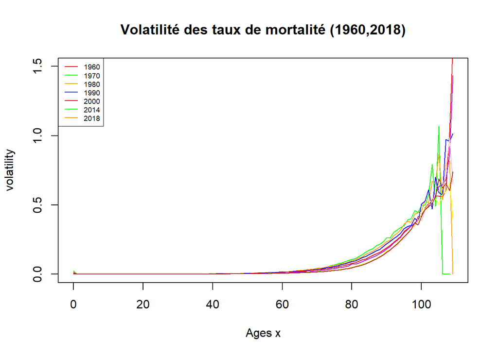

```r
x <- UK$age[0:110]


plot(x, UK$rate$total[0:110,"1960"],
     type='l',
     col='red',
     xlab= "Ages x",
     ylab="volatility",
     ylim=c(0,1.5),
     main ="Volatilité des taux de mortalité (1960,2018)")

lines(x, UK$rate$total[0:110,"1960"], type = 'l', col="green" )
lines(x, UK$rate$total[0:110,"1970"], type = 'l', col='orange' )
lines(x, UK$rate$total[0:110,"1980"], type = 'l', col="blue" )
lines(x, UK$rate$total[0:110,"1990"], type = 'l', col="red" )
lines(x, UK$rate$total[0:110,"2000"], type = 'l', col='purple' )
lines(x, UK$rate$total[0:110,"2010"], type = 'l', col="yellow" )
lines(x, UK$rate$total[0:110,"2014"], type = 'l', col="pink" )
lines(x, UK$rate$total[0:110,"2018"], type = 'l', col='brown' )



legend(x="topleft",
       legend = c("1960","1970","1980","1990","2000","2014","2018"),
       col = c("red","green","orange","blue"),
       lty = 1,
       cex=0.6,
       box.lwd = 0.3)
```

#Vu qu’il y’a une forte volatilité des taux de mortalité pour les âges > 100 c’est pour cette raison que nous allons nous limiter à x ∈ [0, 100].

```r
#plage d'âges
ages.fit = 0:100
#période de calibration
years.fit = 1960:2018
```

```r
# Lissage :
## 1- Spline monotone :
UK_ls_m <- smooth.demogdata(UK,method="mspline")
## 2- Spline standard :
UK_ls_s <- smooth.demogdata(UK, method="spline")
## 3- Spline Concave :
UK_ls_c <- smooth.demogdata(UK, method="cspline")
## 4- Spline localement quadratique :
UK_ls_q <- smooth.demogdata(UK, method="loess")
```

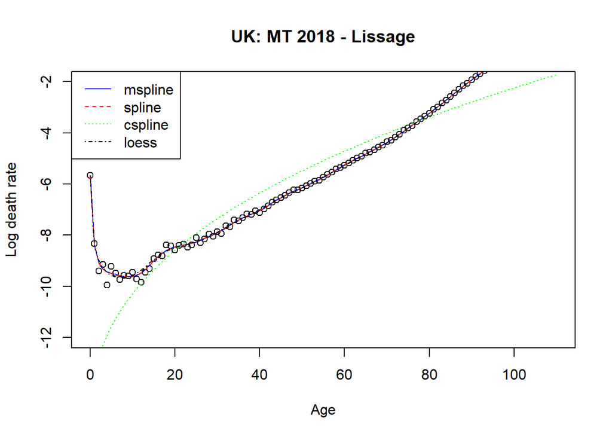

```r
# comparaison :
plot(UK, years=2018, type="p", pch=21, ylim=c(-12, -2), main="UK: MT 2018 - Lissage")
lines(UK_ls_m, years=2018, lty=1, col="blue")
lines(UK_ls_s, years=2018, lty=2, col="red")
lines(UK_ls_c, years=2018, lty=3, col="green")
lines(UK_ls_q, years=2018, lty=4, col="black")
legend("topleft",col=c("blue","red","green","black") ,lty=1:4, leg=c("mspline", "spline","cspline","loess"))
```

# mspline (lissage monotone) et spline représente le mieux la variation du taux de mortalité on peut choisir l’un des deux.

```r
# fitting Lee Carter model :
# séparation des jeux des femmes :
lca.female <- lca(UK_ls_m, series="female", adjust="dt",years =years.fit ,ages = ages.fit)
```

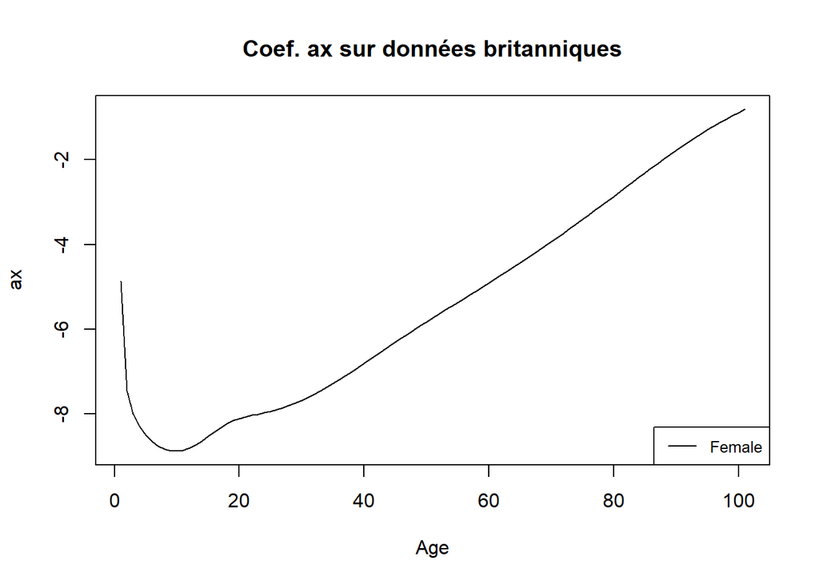

```r
# Paramètre  ax  :
plot(lca.female$ax, main="Coef. ax sur données britanniques", xlab="Age", ylab="ax", type="l")
legend("bottomright", c("Female"), cex=0.8,  lty=1:2)
```

#Ce paramètre ax représente la tendance liée à l’effet isolé de l’âge sur les taux de mortalité(moyenne temporelle du logarithme du taux de mortalité par âge). La courbe de ax suit la tendance des courbes des données empiriques. Les âges faibles ont une décroissance jusqu’à atteindre un minimum absolu à de l’âge de 12 ans, puis une croissance exponentielle a partir de l’age de 60 ans .

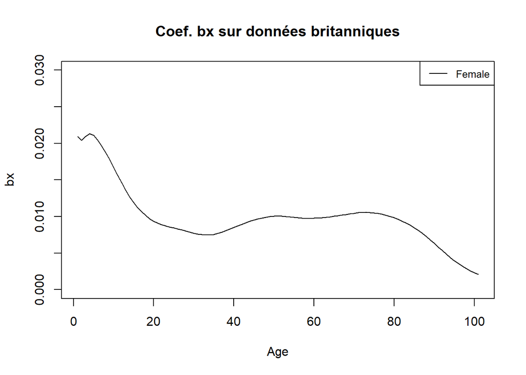

```r
# Paramètre  bx  :
plot(lca.female$bx, main="Coef. bx sur données britanniques", ylim=c(0,0.03),xlab="Age", ylab="bx", type="l")
legend("topright",c("Female"), cex=0.8,  lty=1:2)
```

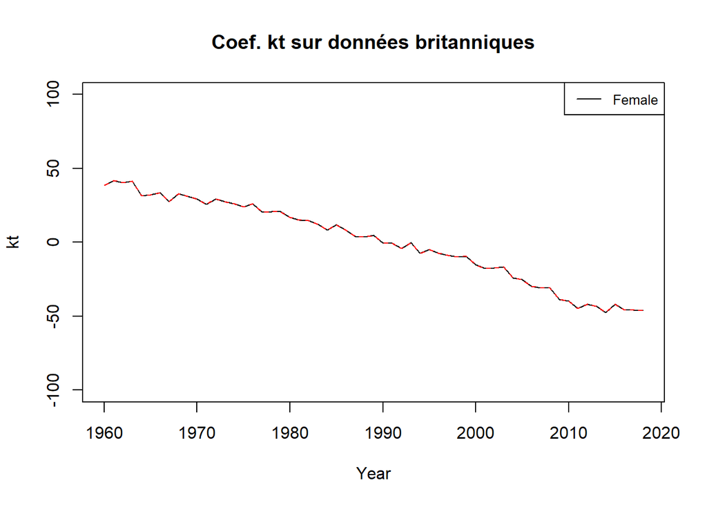

```r
#Paramètre  kt  :
plot(lca.female$kt, xlab="Year", main="Coef. kt sur données britanniques",ylab="kt", type="l",ylim=c(-100, 100))
lines(lca.female$year, y=lca.female$kt, main="kt", lty=2 , col ="red")
legend("topright", c("Female"), cex=0.8, lty=1:2)
```

#La courbe de kt est en baisse constante.

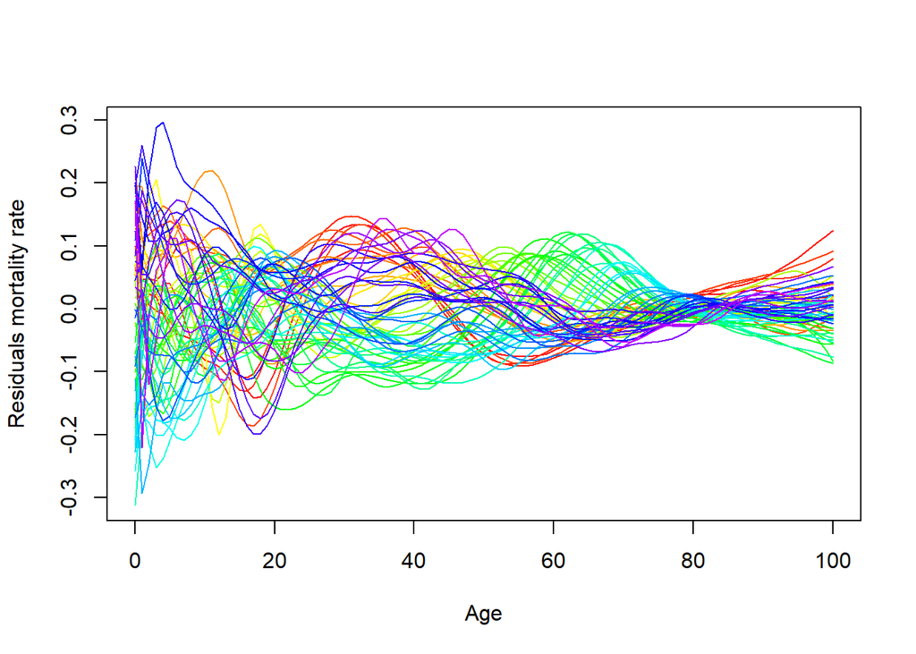

```r
#female
plot(lca.female$residuals)
```

# Intérprétation des résidus : On constate que la variance n’est plus stable pour les ages a partir de 0 à 80 ans et est inférieur à 0.3  
le modéle ne semble pas adapté à la description des taux de mortalité des agés moins de 80 ans.

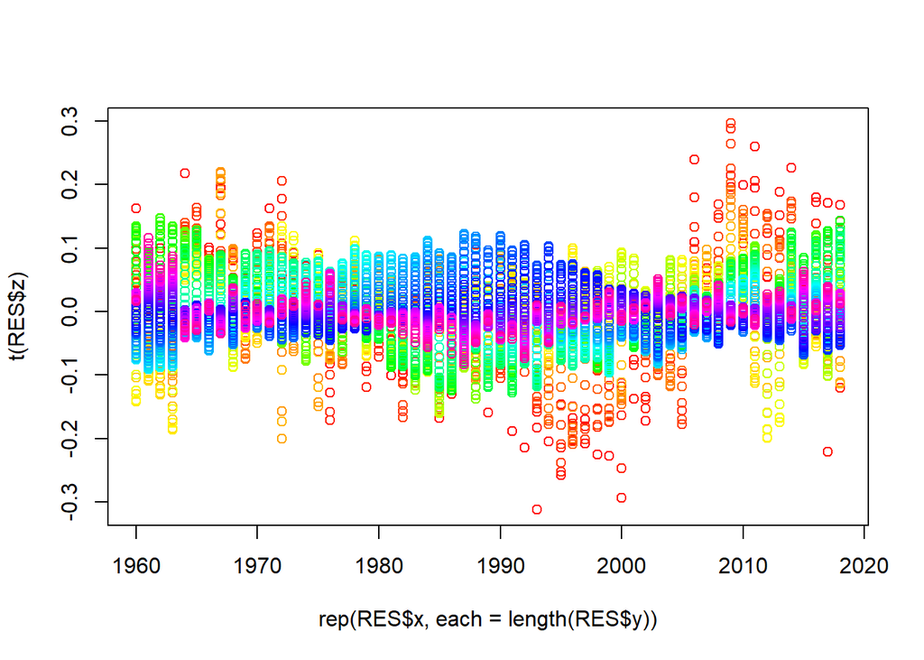

```r
RES=residuals(lca.female,"pearson")
colr=function(k) rainbow(110)[k*100]
couleur=Vectorize(colr)(seq(.01,1,by=.01))
plot(rep(RES$x,each=length(RES$y)),t(RES$z),col=couleur[rep(RES$y,length(RES$x))+1])
```

```r
#En utilisant la fonction fit du package """StMoMo""" :¶
#Le Model de Lee Carter en utilisant le package """StMoMo"""
#Pour les paramétres éstimés on a les memes intérprétations

#________________population féminine________________ :

UK.stmomo.f<-StMoMoData(data=UK_ls_m ,series = "female",type="central")
#ajustement du model (fitiing) :
LC3 <- lc(link = "logit" )
LCfit3 <- fit(LC3, data = central2initial(UK.stmomo.f), ages.fit = ages.fit,  years.fit = years.fit)
```

```
## StMoMo: Start fitting with gnm
## Initialising
## Running start-up iterations..
## Running main iterations............
## Done
## StMoMo: Finish fitting with gnm
```

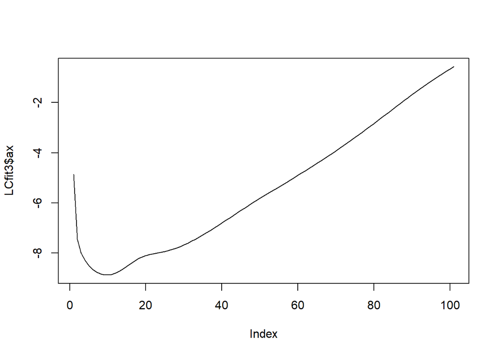

```r
#names(LCfit3)
# paramétre ax :
plot(LCfit3$ax,type='l')
```

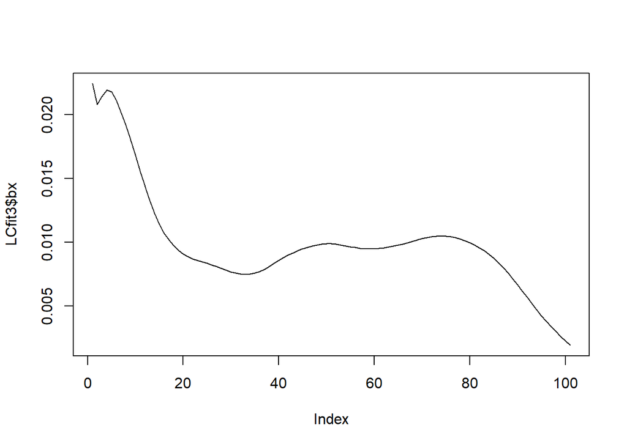

```r
# paramétre bx :
plot(LCfit3$bx,type='l')
```

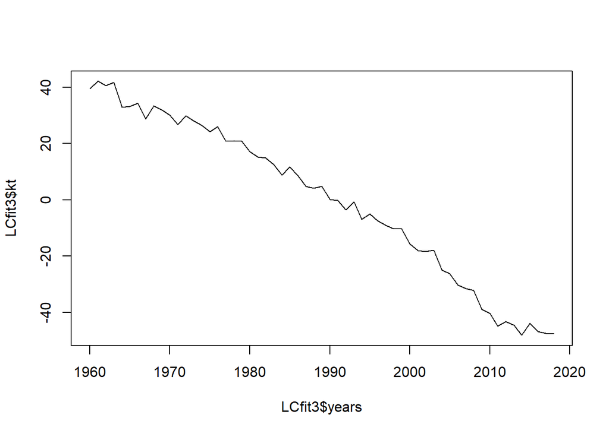

```r
# paramétre kt :
plot(LCfit3$years,LCfit3$kt,type='l')
```

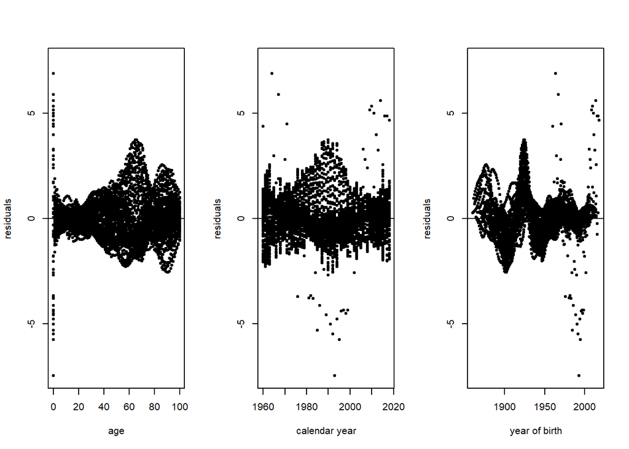

```r
# analyse desidusLelles :
LCres3 <- residuals(LCfit3)
plot(LCres3,type = "scatter") # Scatter plots of deviance residuals for models LC
```

# Question 3

```r
UKSim <- simulate(LCfit3 , h = 25, method=mean,nsim=5000)
print(UKSim)
```

```
## Simulations of Stochastic Mortality Model
## Call: simulate.fitStMoMo(object = LCfit3, nsim = 5000, h = 25, method = mean)
##
## Simulation based on
## Call: fit.StMoMo(object = LC3, data = central2initial(UK.stmomo.f),
## Call:     ages.fit = ages.fit, years.fit = years.fit)
##
## kt model: mrwd
## Jump-off method: fit
## Years in simulation: 2019 - 2043
## Ages in simulation: 0 - 100
##
## Number of paths: 5000
```

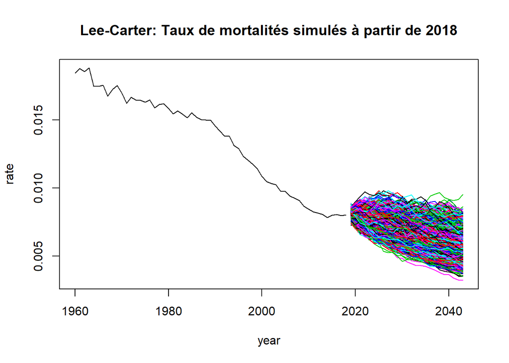

```r
plot(LCfit3$years, (LCfit3$Dxt / LCfit3$Ext)["65", ],
     xlim = range(LCfit3$years, UKSim$years),
     ylim = range((LCfit3$Dxt / LCfit3$Ext)["65", ], UKSim$rates["65", , ]),
     type = "l", xlab = "year", ylab = "rate",
     main = "Lee-Carter: Taux de mortalités simulés à partir de 2018")
matlines(UKSim$years, UKSim$rates["65", , ], type = "l", lty = 1)
```

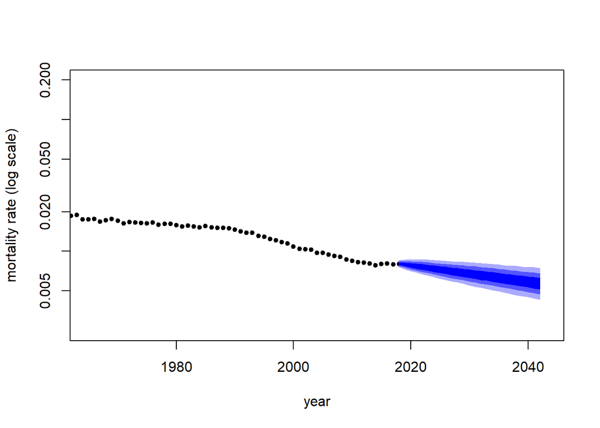

```r
probs = c(2.5, 10, 25, 50, 75, 90, 97.5)

qxt <- LCfit3$Dxt / LCfit3$Ext
matplot(LCfit3$years, t(qxt[c("65", "65", "65"), ]),
 xlim = c(1965, 2043), ylim = c(0.0025, 0.2), pch = 20, col = "black",
 log = "y", xlab = "year", ylab = "mortality rate (log scale)")
fan(t(UKSim$rates["65", , ]), start = 2018, probs = probs, n.fan = 4, fan.col = colorRampPalette(c("blue", "white")), ln = NULL)
```

```r
tab<-read.table(file="fltper_1x1.txt", header = TRUE,skip=1, sep = "", dec = ".")

##### année 2000 ######
UK_2000<- tab[which(tab$Year == 2000),names(tab)]
df_UK_2000<-data.frame(UK_2000)
df_UK_2000$Age<-as.numeric(as.character(df_UK_2000$Age))
df_UK_2000$Age[111]<-110
TD_2000 <- new("lifetable", x=df_UK_2000$Age, lx= df_UK_2000$lx,name="UK")
ESP_2000=exn(TD_2000,x=65)
ESP_2000
```

```
## [1] 18.37765
```

```r
##### année 2010 ######
UK_2010<- tab[which(tab$Year == 2010),names(tab)]
df_UK_2010<-data.frame(UK_2010)
df_UK_2010$Age<-as.numeric(as.character(df_UK_2010$Age))
df_UK_2010$Age[111]<-110
TD_2010 <- new("lifetable", x=df_UK_2010$Age, lx= df_UK_2010$lx,name="UK")
ESP_2010=exn(TD_2010,x=65)
ESP_2010
```

```
## [1] 20.08918
```

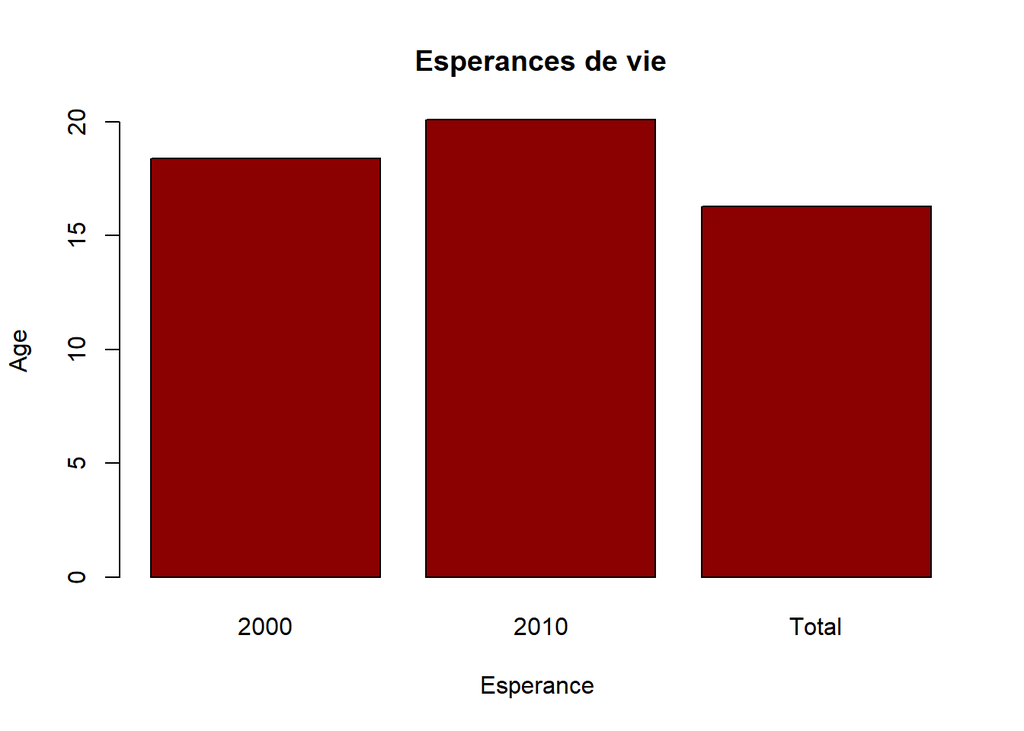

```r
##### la cohorte de toutes les assures d’assurés ######
bar <- subset(tab, Age == 65)
esp_totale=mean(bar$ex)

#### Histograme #####
kk=c(ESP_2000,ESP_2010,esp_totale)
barplot(kk,
main = "Esperances de vie",
xlab = "Esperance ",
ylab = "Age",
names.arg = c("2000","2010","Total"),
col = "darkred",
horiz = FALSE)
```

# On remarque que l’esperance de vie de l’année 2010 est meilleure que l’année 2000 cela s’explique par le #developpement du systeme medicale. Par rapport à l’esperance totale on remarque que sa valeur est en dessous #des deux autres valeurs puisque ca inclut toutes les autres années ou l’esperance de vie est moins importante.

# Question 4

```r
FemaleUK<-read.table(file="fltper_1x1.txt", header = TRUE,skip=1, sep = "", dec = ".")


VAP=function(x,tab,i, year){
        UK_annee<- tab[which(tab$Year == year),names(tab)]
        df_UK_annee<-data.frame(UK_annee)
        df_UK_annee$Age<-as.numeric(as.character(df_UK_annee$Age))
        df_UK_annee$Age[111]<-110
        TD_annee <- new("lifetable", x=df_UK_annee$Age, lx= df_UK_annee$lx,name="UK")
        VAP_f = axn(TD_annee, x=x, i=i,n=25)

        return(VAP_f)
}
#Test de la fonction
print(VAP(60,FemaleUK,0.03,1960))
```

```
## [1] 13.86076
```

#Question 5

```r
VAP_scenario1=VAP(65,FemaleUK,0.03,2000)
VAP_scenario2=VAP(65,FemaleUK,0.03,2010)
c(VAP_scenario1,VAP_scenario2)
```

```
## [1] 13.81222 14.58281
```

```r
mean(c(VAP_scenario1,VAP_scenario2))
```

```
## [1] 14.19751
```

```r
sd(c(VAP_scenario1,VAP_scenario2))
```

```
## [1] 0.5448853
```

#On remarque que la VAP dans le premier scenario calculé sur des personnes ayant 65 ans en 2000 est moins important que # le scenario 2 ou calculé sur des personnes ayant 65 ans en 2010

```r
# Tarification
#les taux de notre cohorte des individus nées en 1960 :
chosen_cohort=1960
lc_historical_rates <- extractCohort(fitted(LCfit3, type = "rates"), cohort = chosen_cohort)

lc_sim_rates <- extractCohort(UKSim$rates,cohort = chosen_cohort)

lc_rates_1960 <- c(lc_historical_rates,lc_sim_rates)

lc_qx_1960 <-mx2qx(lc_rates_1960)


#transformation actuarial table en lifetable:
lc_lifetable_1960 <- probs2lifetable(probs=lc_qx_1960,type = "qx", name = paste("LC","1960","lt",sep="_"))

lc_acttbl_1960<-new("actuarialtable",x=lc_lifetable_1960@x,lx=lc_lifetable_1960@lx)

VAP_hist_projet = axn(lc_acttbl_1960, x=60, n=25) # on a projeté que 25 ans selon le question "3"
VAP_hist_projet
```

```
## [1] 16.22847
```

```r
Prime_Propose = axn(lc_acttbl_1960, x=60, m=25)/axn(lc_acttbl_1960, x=60, m=1,n=25)
Prime_Propose
```

```
## [1] 0.5063644
```

```r
# Bonus :
Provision = axn(lc_acttbl_1960,x=60,m=25) - axn(lc_acttbl_1960,x=60,n=25) * Prime_Propose
Provision
```

```
## [1] -0.3395671
```

#Quesrion6

La VAP dépend de deux facteurs qui sont l’âge de l’assuré et l’interet i

- Par rapport à l’âge la VAP croit en fonction de l’âge (corrélation positive) vu que la probabilité de décès augmente en fonction de ce dernier .
- Par rapport à l’interet: La valeur actuelle probable VAP augmente lorsque le taux technique diminue.